# Flights

#### Those are the columns meaning to easy access when needed.

- Year 2005-2008
- Month 1-12
- DayofMonth 1-31
- DayOfWeek 1 (Monday) - 7 (Sunday)
- DepTime actual departure time (local, hhmm)
- CRSDepTime scheduled departure time (local, hhmm)
- ArrTime actual arrival time (local, hhmm)
- CRSArrTime scheduled arrival time (local, hhmm)
- UniqueCarrier unique carrier code
- FlightNum flight number
- TailNum plane tail number
- ActualElapsedTime in minutes
- CRSElapsedTime in minutes
- AirTime in minutes
- ArrDelay arrival delay, in minutes
- DepDelay departure delay, in minutes
- Origin origin IATA airport code
- Dest destination IATA airport code
- Distance in miles
- TaxiIn taxi in time, in minutes
- TaxiOut taxi out time in minutes
- Cancelled was the flight cancelled?
- CancellationCode reason for cancellation (A = carrier, B = weather, C = NAS, D = security)
- Diverted 1 = yes, 0 = no
- CarrierDelay in minutes
- WeatherDelay in minutes
- NASDelay in minutes
- SecurityDelay in minutes
- LateAircraftDelay in minutes

```python
import pandas as pd
import numpy as np
import random
import matplotlib.pyplot as plt
%matplotlib inline
import seaborn as sns
from time import gmtime
from time import strftime
import datetime
from matplotlib.pyplot import figure
```

```python
#load 2008 data
df = pd.read_csv('2008.csv')
```

lets start by exploring the data sets by cheching the size, null values and more.

```python
df.sample(10)
```

|  | Year | Month | DayofMonth | DayOfWeek | DepTime | CRSDepTime | ArrTime | CRSArrTime | UniqueCarrier | FlightNum | ... | TaxiIn | TaxiOut | Cancelled | CancellationCode | Diverted | CarrierDelay | WeatherDelay | NASDelay | SecurityDelay | LateAircraftDelay |
| --- | --- | --- | --- | --- | --- | --- | --- | --- | --- | --- | --- | --- | --- | --- | --- | --- | --- | --- | --- | --- | --- |
| 5339254 | 2008 | 9 | 18 | 4 | 1431.0 | 1440 | 1626.0 | 1651 | B6 | 1126 | ... | 5.0 | 12.0 | 0 | NaN | 0 | NaN | NaN | NaN | NaN | NaN |
| 6383823 | 2008 | 11 | 16 | 7 | 1925.0 | 1925 | 2019.0 | 2025 | AA | 1486 | ... | 6.0 | 15.0 | 0 | NaN | 0 | NaN | NaN | NaN | NaN | NaN |
| 479989 | 2008 | 1 | 14 | 1 | 1511.0 | 1520 | 1910.0 | 1910 | AA | 283 | ... | 5.0 | 19.0 | 0 | NaN | 0 | NaN | NaN | NaN | NaN | NaN |
| 5988268 | 2008 | 11 | 17 | 1 | 2022.0 | 2015 | 2032.0 | 2040 | WN | 3582 | ... | 8.0 | 8.0 | 0 | NaN | 0 | NaN | NaN | NaN | NaN | NaN |
| 1922939 | 2008 | 4 | 7 | 1 | 555.0 | 600 | 611.0 | 620 | YV | 2802 | ... | 5.0 | 11.0 | 0 | NaN | 0 | NaN | NaN | NaN | NaN | NaN |
| 5040583 | 2008 | 9 | 9 | 2 | 826.0 | 835 | 1425.0 | 1429 | UA | 106 | ... | 12.0 | 19.0 | 0 | NaN | 0 | NaN | NaN | NaN | NaN | NaN |
| 3721488 | 2008 | 7 | 18 | 5 | 1529.0 | 1535 | 1706.0 | 1717 | XE | 2937 | ... | 3.0 | 16.0 | 0 | NaN | 0 | NaN | NaN | NaN | NaN | NaN |
| 3025120 | 2008 | 6 | 11 | 3 | 1242.0 | 1235 | 1512.0 | 1520 | WN | 3422 | ... | 9.0 | 6.0 | 0 | NaN | 0 | NaN | NaN | NaN | NaN | NaN |
| 756835 | 2008 | 2 | 16 | 6 | 1530.0 | 1530 | 1747.0 | 1757 | OH | 4988 | ... | 7.0 | 19.0 | 0 | NaN | 0 | NaN | NaN | NaN | NaN | NaN |
| 2126634 | 2008 | 4 | 14 | 1 | 845.0 | 851 | 855.0 | 904 | EV | 4842 | ... | 4.0 | 17.0 | 0 | NaN | 0 | NaN | NaN | NaN | NaN | NaN |

10 rows × 29 columns

```python
df.shape[0]
```

```
7009728
```

```python
df.info()
```

```
<class 'pandas.core.frame.DataFrame'>
RangeIndex: 7009728 entries, 0 to 7009727
Data columns (total 29 columns):
Year                 int64
Month                int64
DayofMonth           int64
DayOfWeek            int64
DepTime              float64
CRSDepTime           int64
ArrTime              float64
CRSArrTime           int64
UniqueCarrier        object
FlightNum            int64
TailNum              object
ActualElapsedTime    float64
CRSElapsedTime       float64
AirTime              float64
ArrDelay             float64
DepDelay             float64
Origin               object
Dest                 object
Distance             int64
TaxiIn               float64
TaxiOut              float64
Cancelled            int64
CancellationCode     object
Diverted             int64
CarrierDelay         float64
WeatherDelay         float64
NASDelay             float64
SecurityDelay        float64
LateAircraftDelay    float64
dtypes: float64(14), int64(10), object(5)
memory usage: 1.5+ GB
```

> For this project, I will select few UniqueCarrier to have functional number of records

```python
df['UniqueCarrier'].value_counts()
```

```
WN    1201754
AA     604885
OO     567159
MQ     490693
US     453589
DL     451931
UA     449515
XE     374510
NW     347652
CO     298455
EV     280575
9E     262208
FL     261684
YV     254930
OH     197607
B6     196091
AS     151102
F9      95762
HA      61826
AQ       7800
Name: UniqueCarrier, dtype: int64
```

> AQ will be used in this project

```python
df_new = df[(df['UniqueCarrier']=='AQ')]
```

```python
#test
df_new['UniqueCarrier'].value_counts()
```

```
AQ    7800
Name: UniqueCarrier, dtype: int64
```

```python
#save the dataset into csv format
df_new.to_csv('2008_new.csv')
```

```python
#read the new file as df
df = pd.read_csv('2008_new.csv')
df
```

|  | Unnamed: 0 | Year | Month | DayofMonth | DayOfWeek | DepTime | CRSDepTime | ArrTime | CRSArrTime | UniqueCarrier | ... | TaxiIn | TaxiOut | Cancelled | CancellationCode | Diverted | CarrierDelay | WeatherDelay | NASDelay | SecurityDelay | LateAircraftDelay |
| --- | --- | --- | --- | --- | --- | --- | --- | --- | --- | --- | --- | --- | --- | --- | --- | --- | --- | --- | --- | --- | --- |
| 0 | 529526 | 2008 | 1 | 1 | 2 | 1537.0 | 1505 | 1615.0 | 1542 | AQ | ... | 3.0 | 6.0 | 0 | NaN | 0 | 11.0 | 0.0 | 0.0 | 0.0 | 22.0 |
| 1 | 529527 | 2008 | 1 | 2 | 3 | 1510.0 | 1505 | 1552.0 | 1542 | AQ | ... | 4.0 | 15.0 | 0 | NaN | 0 | NaN | NaN | NaN | NaN | NaN |
| 2 | 529528 | 2008 | 1 | 3 | 4 | 1503.0 | 1505 | 1540.0 | 1542 | AQ | ... | 4.0 | 10.0 | 0 | NaN | 0 | NaN | NaN | NaN | NaN | NaN |
| 3 | 529529 | 2008 | 1 | 4 | 5 | 1506.0 | 1505 | 1547.0 | 1542 | AQ | ... | 9.0 | 9.0 | 0 | NaN | 0 | NaN | NaN | NaN | NaN | NaN |
| 4 | 529530 | 2008 | 1 | 5 | 6 | 1505.0 | 1505 | 1542.0 | 1542 | AQ | ... | 3.0 | 11.0 | 0 | NaN | 0 | NaN | NaN | NaN | NaN | NaN |
| 5 | 529531 | 2008 | 1 | 6 | 7 | 1500.0 | 1505 | 1534.0 | 1542 | AQ | ... | 5.0 | 8.0 | 0 | NaN | 0 | NaN | NaN | NaN | NaN | NaN |
| 6 | 529532 | 2008 | 1 | 7 | 1 | 1502.0 | 1505 | 1536.0 | 1542 | AQ | ... | 4.0 | 7.0 | 0 | NaN | 0 | NaN | NaN | NaN | NaN | NaN |
| 7 | 529533 | 2008 | 1 | 8 | 2 | 1455.0 | 1505 | 1535.0 | 1542 | AQ | ... | 4.0 | 5.0 | 0 | NaN | 0 | NaN | NaN | NaN | NaN | NaN |
| 8 | 529534 | 2008 | 1 | 9 | 3 | 1500.0 | 1505 | 1539.0 | 1542 | AQ | ... | 3.0 | 11.0 | 0 | NaN | 0 | NaN | NaN | NaN | NaN | NaN |
| 9 | 529535 | 2008 | 1 | 10 | 4 | 1510.0 | 1505 | 1553.0 | 1542 | AQ | ... | 4.0 | 4.0 | 0 | NaN | 0 | NaN | NaN | NaN | NaN | NaN |
| 10 | 529536 | 2008 | 1 | 11 | 5 | 1515.0 | 1505 | 1551.0 | 1542 | AQ | ... | 4.0 | 12.0 | 0 | NaN | 0 | NaN | NaN | NaN | NaN | NaN |
| 11 | 529537 | 2008 | 1 | 12 | 6 | 1500.0 | 1505 | 1534.0 | 1542 | AQ | ... | 4.0 | 9.0 | 0 | NaN | 0 | NaN | NaN | NaN | NaN | NaN |
| 12 | 529538 | 2008 | 1 | 13 | 7 | 1501.0 | 1505 | 1542.0 | 1542 | AQ | ... | 5.0 | 14.0 | 0 | NaN | 0 | NaN | NaN | NaN | NaN | NaN |
| 13 | 529539 | 2008 | 1 | 14 | 1 | 1500.0 | 1505 | 1537.0 | 1542 | AQ | ... | 4.0 | 11.0 | 0 | NaN | 0 | NaN | NaN | NaN | NaN | NaN |
| 14 | 529540 | 2008 | 1 | 15 | 2 | 1500.0 | 1505 | 1537.0 | 1542 | AQ | ... | 2.0 | 13.0 | 0 | NaN | 0 | NaN | NaN | NaN | NaN | NaN |
| 15 | 529541 | 2008 | 1 | 16 | 3 | 1459.0 | 1505 | 1538.0 | 1542 | AQ | ... | 3.0 | 13.0 | 0 | NaN | 0 | NaN | NaN | NaN | NaN | NaN |
| 16 | 529542 | 2008 | 1 | 17 | 4 | 1502.0 | 1505 | 1537.0 | 1542 | AQ | ... | 3.0 | 10.0 | 0 | NaN | 0 | NaN | NaN | NaN | NaN | NaN |
| 17 | 529543 | 2008 | 1 | 18 | 5 | 1504.0 | 1505 | 1537.0 | 1542 | AQ | ... | 4.0 | 8.0 | 0 | NaN | 0 | NaN | NaN | NaN | NaN | NaN |
| 18 | 529544 | 2008 | 1 | 19 | 6 | 1459.0 | 1505 | 1537.0 | 1542 | AQ | ... | 3.0 | 12.0 | 0 | NaN | 0 | NaN | NaN | NaN | NaN | NaN |
| 19 | 529545 | 2008 | 1 | 20 | 7 | 1503.0 | 1505 | 1538.0 | 1542 | AQ | ... | 4.0 | 7.0 | 0 | NaN | 0 | NaN | NaN | NaN | NaN | NaN |
| 20 | 529546 | 2008 | 1 | 21 | 1 | 1501.0 | 1505 | 1539.0 | 1542 | AQ | ... | 2.0 | 17.0 | 0 | NaN | 0 | NaN | NaN | NaN | NaN | NaN |
| 21 | 529547 | 2008 | 1 | 22 | 2 | 1500.0 | 1505 | 1540.0 | 1542 | AQ | ... | 3.0 | 14.0 | 0 | NaN | 0 | NaN | NaN | NaN | NaN | NaN |
| 22 | 529548 | 2008 | 1 | 23 | 3 | 1502.0 | 1505 | 1539.0 | 1542 | AQ | ... | 4.0 | 12.0 | 0 | NaN | 0 | NaN | NaN | NaN | NaN | NaN |
| 23 | 529549 | 2008 | 1 | 24 | 4 | 1500.0 | 1505 | 1534.0 | 1542 | AQ | ... | 3.0 | 13.0 | 0 | NaN | 0 | NaN | NaN | NaN | NaN | NaN |
| 24 | 529550 | 2008 | 1 | 25 | 5 | 1508.0 | 1505 | 1544.0 | 1542 | AQ | ... | 3.0 | 10.0 | 0 | NaN | 0 | NaN | NaN | NaN | NaN | NaN |
| 25 | 529551 | 2008 | 1 | 26 | 6 | 1457.0 | 1505 | 1534.0 | 1542 | AQ | ... | 5.0 | 10.0 | 0 | NaN | 0 | NaN | NaN | NaN | NaN | NaN |
| 26 | 529552 | 2008 | 1 | 27 | 7 | 1505.0 | 1505 | 1536.0 | 1542 | AQ | ... | 3.0 | 5.0 | 0 | NaN | 0 | NaN | NaN | NaN | NaN | NaN |
| 27 | 529553 | 2008 | 1 | 28 | 1 | 1458.0 | 1505 | 1535.0 | 1542 | AQ | ... | 3.0 | 10.0 | 0 | NaN | 0 | NaN | NaN | NaN | NaN | NaN |
| 28 | 529554 | 2008 | 1 | 29 | 2 | 1501.0 | 1505 | 1536.0 | 1542 | AQ | ... | 3.0 | 6.0 | 0 | NaN | 0 | NaN | NaN | NaN | NaN | NaN |
| 29 | 529555 | 2008 | 1 | 30 | 3 | 1457.0 | 1505 | 1533.0 | 1542 | AQ | ... | 3.0 | 8.0 | 0 | NaN | 0 | NaN | NaN | NaN | NaN | NaN |
| ... | ... | ... | ... | ... | ... | ... | ... | ... | ... | ... | ... | ... | ... | ... | ... | ... | ... | ... | ... | ... | ... |
| 7770 | 1105922 | 2008 | 2 | 29 | 5 | 1252.0 | 1250 | 1344.0 | 1337 | AQ | ... | 5.0 | 5.0 | 0 | NaN | 0 | NaN | NaN | NaN | NaN | NaN |
| 7771 | 1105923 | 2008 | 2 | 1 | 5 | 800.0 | 800 | 1214.0 | 1205 | AQ | ... | 3.0 | 8.0 | 0 | NaN | 0 | NaN | NaN | NaN | NaN | NaN |
| 7772 | 1105924 | 2008 | 2 | 2 | 6 | 755.0 | 800 | 1155.0 | 1155 | AQ | ... | 3.0 | 9.0 | 0 | NaN | 0 | NaN | NaN | NaN | NaN | NaN |
| 7773 | 1105925 | 2008 | 2 | 3 | 7 | 752.0 | 800 | 1210.0 | 1205 | AQ | ... | 5.0 | 12.0 | 0 | NaN | 0 | NaN | NaN | NaN | NaN | NaN |
| 7774 | 1105926 | 2008 | 2 | 4 | 1 | 755.0 | 800 | 1223.0 | 1205 | AQ | ... | 7.0 | 14.0 | 0 | NaN | 0 | 0.0 | 0.0 | 18.0 | 0.0 | 0.0 |
| 7775 | 1105927 | 2008 | 2 | 5 | 2 | 758.0 | 800 | 1146.0 | 1155 | AQ | ... | 4.0 | 12.0 | 0 | NaN | 0 | NaN | NaN | NaN | NaN | NaN |
| 7776 | 1105928 | 2008 | 2 | 6 | 3 | 755.0 | 800 | 1156.0 | 1205 | AQ | ... | 3.0 | 12.0 | 0 | NaN | 0 | NaN | NaN | NaN | NaN | NaN |
| 7777 | 1105929 | 2008 | 2 | 7 | 4 | 756.0 | 800 | 1158.0 | 1155 | AQ | ... | 3.0 | 12.0 | 0 | NaN | 0 | NaN | NaN | NaN | NaN | NaN |
| 7778 | 1105930 | 2008 | 2 | 8 | 5 | 800.0 | 800 | 1217.0 | 1205 | AQ | ... | 4.0 | 15.0 | 0 | NaN | 0 | NaN | NaN | NaN | NaN | NaN |
| 7779 | 1105931 | 2008 | 2 | 9 | 6 | 758.0 | 800 | 1153.0 | 1155 | AQ | ... | 3.0 | 12.0 | 0 | NaN | 0 | NaN | NaN | NaN | NaN | NaN |
| 7780 | 1105932 | 2008 | 2 | 10 | 7 | 810.0 | 800 | 1205.0 | 1205 | AQ | ... | 4.0 | 25.0 | 0 | NaN | 0 | NaN | NaN | NaN | NaN | NaN |
| 7781 | 1105933 | 2008 | 2 | 11 | 1 | 830.0 | 800 | 1228.0 | 1205 | AQ | ... | 5.0 | 12.0 | 0 | NaN | 0 | 23.0 | 0.0 | 0.0 | 0.0 | 0.0 |
| 7782 | 1105934 | 2008 | 2 | 12 | 2 | 800.0 | 800 | 1125.0 | 1155 | AQ | ... | 3.0 | 14.0 | 0 | NaN | 0 | NaN | NaN | NaN | NaN | NaN |
| 7783 | 1105935 | 2008 | 2 | 13 | 3 | 800.0 | 800 | 1150.0 | 1205 | AQ | ... | 4.0 | 26.0 | 0 | NaN | 0 | NaN | NaN | NaN | NaN | NaN |
| 7784 | 1105936 | 2008 | 2 | 14 | 4 | 758.0 | 800 | 1132.0 | 1155 | AQ | ... | 3.0 | 19.0 | 0 | NaN | 0 | NaN | NaN | NaN | NaN | NaN |
| 7785 | 1105937 | 2008 | 2 | 15 | 5 | 820.0 | 800 | 1158.0 | 1205 | AQ | ... | 4.0 | 15.0 | 0 | NaN | 0 | NaN | NaN | NaN | NaN | NaN |
| 7786 | 1105938 | 2008 | 2 | 16 | 6 | 800.0 | 800 | 1133.0 | 1155 | AQ | ... | 3.0 | 13.0 | 0 | NaN | 0 | NaN | NaN | NaN | NaN | NaN |
| 7787 | 1105939 | 2008 | 2 | 17 | 7 | 819.0 | 800 | 1201.0 | 1205 | AQ | ... | 3.0 | 14.0 | 0 | NaN | 0 | NaN | NaN | NaN | NaN | NaN |
| 7788 | 1105940 | 2008 | 2 | 18 | 1 | 756.0 | 800 | 1150.0 | 1205 | AQ | ... | 4.0 | 16.0 | 0 | NaN | 0 | NaN | NaN | NaN | NaN | NaN |
| 7789 | 1105941 | 2008 | 2 | 19 | 2 | 800.0 | 800 | 1146.0 | 1155 | AQ | ... | 3.0 | 14.0 | 0 | NaN | 0 | NaN | NaN | NaN | NaN | NaN |
| 7790 | 1105942 | 2008 | 2 | 20 | 3 | 800.0 | 800 | 1202.0 | 1205 | AQ | ... | 4.0 | 12.0 | 0 | NaN | 0 | NaN | NaN | NaN | NaN | NaN |
| 7791 | 1105943 | 2008 | 2 | 21 | 4 | 757.0 | 800 | 1159.0 | 1155 | AQ | ... | 4.0 | 26.0 | 0 | NaN | 0 | NaN | NaN | NaN | NaN | NaN |
| 7792 | 1105944 | 2008 | 2 | 22 | 5 | 759.0 | 800 | 1242.0 | 1205 | AQ | ... | 4.0 | 8.0 | 0 | NaN | 0 | 0.0 | 0.0 | 37.0 | 0.0 | 0.0 |
| 7793 | 1105945 | 2008 | 2 | 23 | 6 | 758.0 | 800 | 1216.0 | 1155 | AQ | ... | 3.0 | 17.0 | 0 | NaN | 0 | 0.0 | 0.0 | 21.0 | 0.0 | 0.0 |
| 7794 | 1105946 | 2008 | 2 | 24 | 7 | 948.0 | 800 | NaN | 1205 | AQ | ... | NaN | 14.0 | 0 | NaN | 1 | NaN | NaN | NaN | NaN | NaN |
| 7795 | 1105947 | 2008 | 2 | 25 | 1 | 758.0 | 800 | 1205.0 | 1205 | AQ | ... | 3.0 | 10.0 | 0 | NaN | 0 | NaN | NaN | NaN | NaN | NaN |
| 7796 | 1105948 | 2008 | 2 | 26 | 2 | 752.0 | 800 | 1145.0 | 1155 | AQ | ... | 4.0 | 15.0 | 0 | NaN | 0 | NaN | NaN | NaN | NaN | NaN |
| 7797 | 1105949 | 2008 | 2 | 27 | 3 | 753.0 | 800 | 1207.0 | 1205 | AQ | ... | 3.0 | 15.0 | 0 | NaN | 0 | NaN | NaN | NaN | NaN | NaN |
| 7798 | 1105950 | 2008 | 2 | 28 | 4 | 751.0 | 800 | 1132.0 | 1155 | AQ | ... | 3.0 | 14.0 | 0 | NaN | 0 | NaN | NaN | NaN | NaN | NaN |
| 7799 | 1105951 | 2008 | 2 | 29 | 5 | 759.0 | 800 | 1208.0 | 1205 | AQ | ... | 5.0 | 20.0 | 0 | NaN | 0 | NaN | NaN | NaN | NaN | NaN |

7800 rows × 30 columns

```python
df.describe()
```

|  | Unnamed: 0 | Year | Month | DayofMonth | DayOfWeek | DepTime | CRSDepTime | ArrTime | CRSArrTime | FlightNum | ... | Distance | TaxiIn | TaxiOut | Cancelled | Diverted | CarrierDelay | WeatherDelay | NASDelay | SecurityDelay | LateAircraftDelay |
| --- | --- | --- | --- | --- | --- | --- | --- | --- | --- | --- | --- | --- | --- | --- | --- | --- | --- | --- | --- | --- | --- |
| count | 7.800000e+03 | 7800.0 | 7800.000000 | 7800.000000 | 7800.000000 | 7758.000000 | 7800.000000 | 7752.000000 | 7800.000000 | 7800.000000 | ... | 7800.000000 | 7752.000000 | 7758.000000 | 7800.000000 | 7800.000000 | 394.000000 | 394.000000 | 394.000000 | 394.000000 | 394.000000 |
| mean | 8.084072e+05 | 2008.0 | 1.483590 | 15.529487 | 3.941667 | 1296.969580 | 1303.010513 | 1398.767157 | 1405.825128 | 215.143205 | ... | 426.262308 | 3.890480 | 8.069090 | 0.005385 | 0.000769 | 22.149746 | 1.494924 | 2.510152 | 0.269036 | 13.624365 |
| std | 2.861293e+05 | 0.0 | 0.499763 | 8.675034 | 1.946142 | 473.506727 | 473.746116 | 508.439710 | 505.745584 | 144.800894 | ... | 758.184530 | 2.400114 | 3.363213 | 0.073187 | 0.027726 | 35.724710 | 10.138794 | 8.397937 | 2.745101 | 30.133224 |
| min | 5.295260e+05 | 2008.0 | 1.000000 | 1.000000 | 1.000000 | 5.000000 | 500.000000 | 2.000000 | 21.000000 | 26.000000 | ... | 76.000000 | 1.000000 | 1.000000 | 0.000000 | 0.000000 | 0.000000 | 0.000000 | 0.000000 | 0.000000 | 0.000000 |
| 25% | 5.314758e+05 | 2008.0 | 1.000000 | 8.000000 | 2.000000 | 908.000000 | 915.000000 | 954.000000 | 958.000000 | 77.000000 | ... | 100.000000 | 3.000000 | 6.000000 | 0.000000 | 0.000000 | 0.000000 | 0.000000 | 0.000000 | 0.000000 | 0.000000 |
| 50% | 5.334255e+05 | 2008.0 | 1.000000 | 16.000000 | 4.000000 | 1304.500000 | 1300.000000 | 1358.000000 | 1357.000000 | 216.000000 | ... | 163.000000 | 4.000000 | 7.000000 | 0.000000 | 0.000000 | 16.000000 | 0.000000 | 0.000000 | 0.000000 | 0.000000 |
| 75% | 1.104001e+06 | 2008.0 | 2.000000 | 23.000000 | 6.000000 | 1655.000000 | 1655.000000 | 1825.000000 | 1832.000000 | 270.000000 | ... | 216.000000 | 4.000000 | 10.000000 | 0.000000 | 0.000000 | 30.000000 | 0.000000 | 0.000000 | 0.000000 | 19.000000 |
| max | 1.105951e+06 | 2008.0 | 2.000000 | 31.000000 | 7.000000 | 2350.000000 | 2312.000000 | 2400.000000 | 2355.000000 | 489.000000 | ... | 2677.000000 | 66.000000 | 49.000000 | 1.000000 | 1.000000 | 338.000000 | 97.000000 | 79.000000 | 35.000000 | 269.000000 |

8 rows × 25 columns

```python
sum(df.duplicated())
```

```
0
```

#### Assessing the data

> fix the data types of the data

> fix the date and combain the year month and date

> fix the time format

> fix the days by changing the number to the actal day name

```python
#change to integer to remove .
df['DepTime']=df['DepTime'].fillna(0).astype(int)
df['CRSDepTime']=df['CRSDepTime'].fillna(0).astype(int)
df['ArrTime']=df['ArrTime'].fillna(0).astype(int)
df['CRSArrTime']=df['CRSArrTime'].fillna(0).astype(int)
```

```python
#check nulls
df['DepTime'].isna().sum(),df['CRSDepTime'].isna().sum(),df['ArrTime'].isna().sum(),df['CRSArrTime'].isna().sum()
```

```
(0, 0, 0, 0)
```

```python
#change the type of the data in each column needed
df['Year']=df['Year'].astype(str)
df['Month']=df['Month'].astype(str)
df['DayofMonth']=df['DayofMonth'].astype(str)
df['DayOfWeek']=df['DayOfWeek'].astype(str)
df['DepTime']=df['DepTime'].astype(str)
df['CRSDepTime']=df['CRSDepTime'].astype(str)
df['ArrTime']=df['ArrTime'].astype(str)
df['CRSArrTime']=df['CRSArrTime'].astype(str)
df['FlightNum']=df['FlightNum'].astype(str)
df['ActualElapsedTime']=df['ActualElapsedTime'].astype(str)
df['CRSElapsedTime']=df['CRSElapsedTime'].astype(str)
df['AirTime']=df['AirTime'].astype(str)
df['ArrDelay']=df['ArrDelay'].astype(str)
df['DepDelay']=df['DepDelay'].astype(str)
df['Distance']=df['Distance'].astype(str)
df['TaxiOut']=df['TaxiOut'].astype(str)
df['Cancelled']=df['Cancelled'].astype(str)
df['Diverted']=df['Diverted'].astype(str)
```

```python
#test
df.info()
```

```
<class 'pandas.core.frame.DataFrame'>
RangeIndex: 7800 entries, 0 to 7799
Data columns (total 30 columns):
Unnamed: 0           7800 non-null int64
Year                 7800 non-null object
Month                7800 non-null object
DayofMonth           7800 non-null object
DayOfWeek            7800 non-null object
DepTime              7800 non-null object
CRSDepTime           7800 non-null object
ArrTime              7800 non-null object
CRSArrTime           7800 non-null object
UniqueCarrier        7800 non-null object
FlightNum            7800 non-null object
TailNum              7778 non-null object
ActualElapsedTime    7800 non-null object
CRSElapsedTime       7800 non-null object
AirTime              7800 non-null object
ArrDelay             7800 non-null object
DepDelay             7800 non-null object
Origin               7800 non-null object
Dest                 7800 non-null object
Distance             7800 non-null object
TaxiIn               7752 non-null float64
TaxiOut              7800 non-null object
Cancelled            7800 non-null object
CancellationCode     42 non-null object
Diverted             7800 non-null object
CarrierDelay         394 non-null float64
WeatherDelay         394 non-null float64
NASDelay             394 non-null float64
SecurityDelay        394 non-null float64
LateAircraftDelay    394 non-null float64
dtypes: float64(6), int64(1), object(23)
memory usage: 1.8+ MB
```

```python
#fix the date format then will drop year , month, and DayofMonth columns

df['Date'] = df['Year'] + '-' + df['Month']+ '-' + df['DayofMonth']
```

```python
#drop columns
columns = ['Year','Month','DayofMonth']

df = df.drop(columns, axis=1)
#test
df.head(2)
```

|  | Unnamed: 0 | DayOfWeek | DepTime | CRSDepTime | ArrTime | CRSArrTime | UniqueCarrier | FlightNum | TailNum | ActualElapsedTime | ... | TaxiOut | Cancelled | CancellationCode | Diverted | CarrierDelay | WeatherDelay | NASDelay | SecurityDelay | LateAircraftDelay | Date |
| --- | --- | --- | --- | --- | --- | --- | --- | --- | --- | --- | --- | --- | --- | --- | --- | --- | --- | --- | --- | --- | --- |
| 0 | 529526 | 2 | 1537 | 1505 | 1615 | 1542 | AQ | 26 | N810AL | 38.0 | ... | 6.0 | 0 | NaN | 0 | 11.0 | 0.0 | 0.0 | 0.0 | 22.0 | 2008-1-1 |
| 1 | 529527 | 3 | 1510 | 1505 | 1552 | 1542 | AQ | 26 | N824AL | 42.0 | ... | 15.0 | 0 | NaN | 0 | NaN | NaN | NaN | NaN | NaN | 2008-1-2 |

2 rows × 28 columns

```python
#fix the dayofweek values
df['DayOfWeek'] =  df['DayOfWeek'].replace('1','Monday')
df['DayOfWeek'] =  df['DayOfWeek'].replace('2','Tuesday')
df['DayOfWeek'] =  df['DayOfWeek'].replace('3','Wendesday')
df['DayOfWeek'] =  df['DayOfWeek'].replace('4','Tursday')
df['DayOfWeek'] =  df['DayOfWeek'].replace('5','Friday')
df['DayOfWeek'] =  df['DayOfWeek'].replace('6','Saturday')
df['DayOfWeek'] =  df['DayOfWeek'].replace('7','Sunday')
```

```python
#test
df['DayOfWeek'].value_counts()
```

```
Tursday      1182
Friday       1182
Tuesday      1178
Wendesday    1177
Monday       1050
Saturday     1047
Sunday        984
Name: DayOfWeek, dtype: int64
```

```python
#add zero if the length of DepTime is 4
for row in df['DepTime']:
    if len(row) == 3:
        df['DepTime']=df['DepTime'].str[0:3]+'0'

df.head(2)
```

|  | Unnamed: 0 | DayOfWeek | DepTime | CRSDepTime | ArrTime | CRSArrTime | UniqueCarrier | FlightNum | TailNum | ActualElapsedTime | ... | TaxiOut | Cancelled | CancellationCode | Diverted | CarrierDelay | WeatherDelay | NASDelay | SecurityDelay | LateAircraftDelay | Date |
| --- | --- | --- | --- | --- | --- | --- | --- | --- | --- | --- | --- | --- | --- | --- | --- | --- | --- | --- | --- | --- | --- |
| 0 | 529526 | Tuesday | 1530 | 1505 | 1615 | 1542 | AQ | 26 | N810AL | 38.0 | ... | 6.0 | 0 | NaN | 0 | 11.0 | 0.0 | 0.0 | 0.0 | 22.0 | 2008-1-1 |
| 1 | 529527 | Wendesday | 1510 | 1505 | 1552 | 1542 | AQ | 26 | N824AL | 42.0 | ... | 15.0 | 0 | NaN | 0 | NaN | NaN | NaN | NaN | NaN | 2008-1-2 |

2 rows × 28 columns

```python
#add zero if the length of CRSDepTime is 4
for row in df['CRSDepTime']:
    if len(row) == 3:
        df['CRSDepTime']=df['CRSDepTime'].str[0:3]+'0'

df.head(2)
```

|  | Unnamed: 0 | DayOfWeek | DepTime | CRSDepTime | ArrTime | CRSArrTime | UniqueCarrier | FlightNum | TailNum | ActualElapsedTime | ... | TaxiOut | Cancelled | CancellationCode | Diverted | CarrierDelay | WeatherDelay | NASDelay | SecurityDelay | LateAircraftDelay | Date |
| --- | --- | --- | --- | --- | --- | --- | --- | --- | --- | --- | --- | --- | --- | --- | --- | --- | --- | --- | --- | --- | --- |
| 0 | 529526 | Tuesday | 1530 | 1500 | 1615 | 1542 | AQ | 26 | N810AL | 38.0 | ... | 6.0 | 0 | NaN | 0 | 11.0 | 0.0 | 0.0 | 0.0 | 22.0 | 2008-1-1 |
| 1 | 529527 | Wendesday | 1510 | 1500 | 1552 | 1542 | AQ | 26 | N824AL | 42.0 | ... | 15.0 | 0 | NaN | 0 | NaN | NaN | NaN | NaN | NaN | 2008-1-2 |

2 rows × 28 columns

```python
#add zero if the length of ArrTime is 4
for row in df['ArrTime']:
    if len(row) == 3:
        df['ArrTime']=df['ArrTime'].str[0:3]+'0'

df.head(2)
```

|  | Unnamed: 0 | DayOfWeek | DepTime | CRSDepTime | ArrTime | CRSArrTime | UniqueCarrier | FlightNum | TailNum | ActualElapsedTime | ... | TaxiOut | Cancelled | CancellationCode | Diverted | CarrierDelay | WeatherDelay | NASDelay | SecurityDelay | LateAircraftDelay | Date |
| --- | --- | --- | --- | --- | --- | --- | --- | --- | --- | --- | --- | --- | --- | --- | --- | --- | --- | --- | --- | --- | --- |
| 0 | 529526 | Tuesday | 1530 | 1500 | 1610 | 1542 | AQ | 26 | N810AL | 38.0 | ... | 6.0 | 0 | NaN | 0 | 11.0 | 0.0 | 0.0 | 0.0 | 22.0 | 2008-1-1 |
| 1 | 529527 | Wendesday | 1510 | 1500 | 1550 | 1542 | AQ | 26 | N824AL | 42.0 | ... | 15.0 | 0 | NaN | 0 | NaN | NaN | NaN | NaN | NaN | 2008-1-2 |

2 rows × 28 columns

```python
#add zero if the length of CRSArrTime is 4
for row in df['CRSArrTime']:
    if len(row) == 3:
        df['CRSArrTime']=df['CRSArrTime'].str[0:3]+'0'

df.head(2)
```

|  | Unnamed: 0 | DayOfWeek | DepTime | CRSDepTime | ArrTime | CRSArrTime | UniqueCarrier | FlightNum | TailNum | ActualElapsedTime | ... | TaxiOut | Cancelled | CancellationCode | Diverted | CarrierDelay | WeatherDelay | NASDelay | SecurityDelay | LateAircraftDelay | Date |
| --- | --- | --- | --- | --- | --- | --- | --- | --- | --- | --- | --- | --- | --- | --- | --- | --- | --- | --- | --- | --- | --- |
| 0 | 529526 | Tuesday | 1530 | 1500 | 1610 | 1540 | AQ | 26 | N810AL | 38.0 | ... | 6.0 | 0 | NaN | 0 | 11.0 | 0.0 | 0.0 | 0.0 | 22.0 | 2008-1-1 |
| 1 | 529527 | Wendesday | 1510 | 1500 | 1550 | 1540 | AQ | 26 | N824AL | 42.0 | ... | 15.0 | 0 | NaN | 0 | NaN | NaN | NaN | NaN | NaN | 2008-1-2 |

2 rows × 28 columns

```python
#fix the end of the time as hhmmss format
df['DepTime']=df['DepTime'].str[0:2]+':'+df['DepTime'].str[2:4]+':00'
df['CRSDepTime']=df['CRSDepTime'].str[0:2]+':'+df['CRSDepTime'].str[2:4]+':00'
df['ArrTime']=df['ArrTime'].str[0:2]+':'+df['ArrTime'].str[2:4]+':00'
df['CRSArrTime']=df['CRSArrTime'].str[0:2]+':'+df['CRSArrTime'].str[2:4]+':00'
df.head(2)
```

|  | Unnamed: 0 | DayOfWeek | DepTime | CRSDepTime | ArrTime | CRSArrTime | UniqueCarrier | FlightNum | TailNum | ActualElapsedTime | ... | TaxiOut | Cancelled | CancellationCode | Diverted | CarrierDelay | WeatherDelay | NASDelay | SecurityDelay | LateAircraftDelay | Date |
| --- | --- | --- | --- | --- | --- | --- | --- | --- | --- | --- | --- | --- | --- | --- | --- | --- | --- | --- | --- | --- | --- |
| 0 | 529526 | Tuesday | 15:30:00 | 15:00:00 | 16:10:00 | 15:40:00 | AQ | 26 | N810AL | 38.0 | ... | 6.0 | 0 | NaN | 0 | 11.0 | 0.0 | 0.0 | 0.0 | 22.0 | 2008-1-1 |
| 1 | 529527 | Wendesday | 15:10:00 | 15:00:00 | 15:50:00 | 15:40:00 | AQ | 26 | N824AL | 42.0 | ... | 15.0 | 0 | NaN | 0 | NaN | NaN | NaN | NaN | NaN | 2008-1-2 |

2 rows × 28 columns

```python
df.info()
```

[output not shown]

```python
#uneeded columns
df = df.drop(['Unnamed: 0','TaxiIn','TaxiOut','CarrierDelay','WeatherDelay','NASDelay','SecurityDelay','LateAircraftDelay'], axis=1)
df.head(2)
```

[output not shown]

```python
#Save the dataframe that will be used
df.to_csv('aq.csv')
```

```python
#read from the new dataframe
df = pd.read_csv('aq.csv')
df.head(4)
```

|  | Unnamed: 0 | DayOfWeek | DepTime | CRSDepTime | ArrTime | CRSArrTime | UniqueCarrier | FlightNum | TailNum | ActualElapsedTime | ... | AirTime | ArrDelay | DepDelay | Origin | Dest | Distance | Cancelled | CancellationCode | Diverted | Date |
| --- | --- | --- | --- | --- | --- | --- | --- | --- | --- | --- | --- | --- | --- | --- | --- | --- | --- | --- | --- | --- | --- |
| 0 | 0 | Tuesday | 15:30:00.000000000 | 15:00:00.000000000 | 16:10:00.000000000 | 15:40:00.000000000 | AQ | 26 | N810AL | 38.0 | ... | 29.0 | 33.0 | 32.0 | HNL | OGG | 100 | 0 | NaN | 0 | 2008-1-1 |
| 1 | 1 | Wendesday | 15:10:00.000000000 | 15:00:00.000000000 | 15:50:00.000000000 | 15:40:00.000000000 | AQ | 26 | N824AL | 42.0 | ... | 23.0 | 10.0 | 5.0 | HNL | OGG | 100 | 0 | NaN | 0 | 2008-1-2 |
| 2 | 2 | Tursday | 15:00:00.000000000 | 15:00:00.000000000 | 15:40:00.000000000 | 15:40:00.000000000 | AQ | 26 | N824AL | 37.0 | ... | 23.0 | -2.0 | -2.0 | HNL | OGG | 100 | 0 | NaN | 0 | 2008-1-3 |
| 3 | 3 | Friday | 15:00:00.000000000 | 15:00:00.000000000 | 15:40:00.000000000 | 15:40:00.000000000 | AQ | 26 | N810AL | 41.0 | ... | 23.0 | 5.0 | 1.0 | HNL | OGG | 100 | 0 | NaN | 0 | 2008-1-4 |

4 rows × 21 columns

```python
df = df.drop(['Unnamed: 0','DepTime','CRSDepTime','ArrTime','CRSArrTime','ActualElapsedTime','CRSElapsedTime'],axis=1)
df.info()
```

[output not shown]

##### Will drop negative values

```python
df = df[df['DepDelay'] >= 0]
df = df[df['ArrDelay'] >=0]
df.shape[0]
```

```
1418
```

### Now lets start exploring

##### General scatter matrix to check the relation between the columns

```python
pd.plotting.scatter_matrix(df,figsize=(150,150))
```

[output not shown]

[output cut: 49 more lines]

[output not shown]

```
array([[<matplotlib.axes._subplots.AxesSubplot object at 0x000001CC034482E8>,
      dtype=object)
```

[figure not shown]

##### Create a histogram for all the data to check the actual relation in the variables inside each column

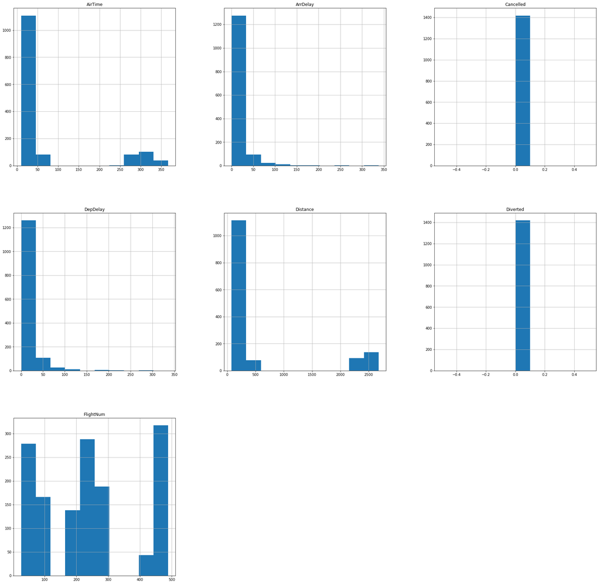

```python
df.hist(figsize=(30,30));
```

##### Histogram of Tail Number of planes

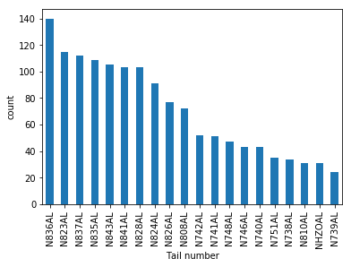

```python
base_color = sns.color_palette()[0]
df['TailNum'].value_counts().plot(kind='bar', color = base_color,label="Tail Numbers")
plt.xlabel("Tail number")
plt.ylabel("count");
```

##### Create histogram for the distance

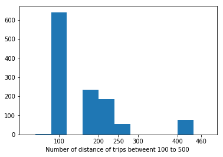

```python
bins = np.arange(0,df['Distance'].max()+40,40)
plt.hist(data = df, x='Distance',bins=bins)
ticks = [100,200 ,250,300,400, 460]
labels = ['{}'.format(val) for val in ticks]
plt.xticks(ticks, labels)
plt.xlabel('Number of distance of trips betweent 100 to 500 ')
plt.xlim(0,500);
```

##### Note that the bin size is changed for the next graph

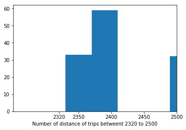

```python
bins = np.arange(250,df['Distance'].max(),40)
plt.hist(data = df, x='Distance',bins=bins)
ticks = [2320,2350,2400 ,2450,2500]
labels = ['{}'.format(val) for val in ticks]
plt.xticks(ticks, labels)
plt.xlabel('Number of distance of trips betweent 2320 to 2500')
plt.xlim(2250,2500);
```

##### As we can see in distance most of the trips are around 100 to 450 miles.

##### Create a histogram for the week days

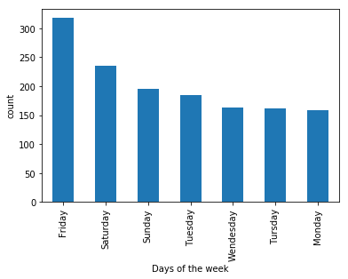

```python
base_color = sns.color_palette()[0]
df['DayOfWeek'].value_counts().plot(kind='bar', color = base_color,label="Days of the week")
plt.xlabel("Days of the week")
plt.ylabel("count");
```

##### Explanotry Visiualization

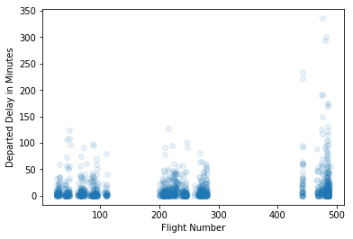

```python
sns.regplot(data = df, x = 'FlightNum', y = 'DepDelay', fit_reg = False,
           x_jitter = 0.2, y_jitter = 0.2, scatter_kws = {'alpha' : 1/10})
plt.xlabel('Flight Number')
plt.ylabel('Departed Delay in Minutes')
```

##### The flights numbers between 450 to 500 are the most delayed flights with max 350 minutes of delay

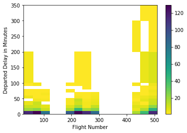

```python
bins_x = [26,60,90,120,150,180,210,240,270,300,330,360,390,420,450,480,510]
bins_y = [0,10,20,30,40,50,60,70,80,90,100,200,300,350]
plt.hist2d(data = df, x = 'FlightNum', y = 'DepDelay',cmin=0.5,cmap = 'viridis_r', bins = [bins_x, bins_y])
plt.colorbar()
plt.xlabel('Flight Number')
plt.ylabel('Departed Delay in Minutes')
```

#### The relation ship between the arrival delay and departed delay are positve as if the plane is departed late by default the arrival will be late

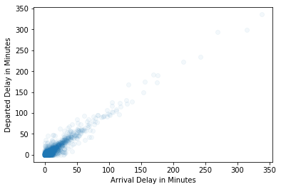

```python
sns.regplot(data = df, x = 'ArrDelay', y = 'DepDelay', fit_reg = False,
           x_jitter = 0.2, y_jitter = 0.2, scatter_kws = {'alpha' : 1/20})
plt.xlabel('Arrival Delay in Minutes')
plt.ylabel('Departed Delay in Minutes')
```

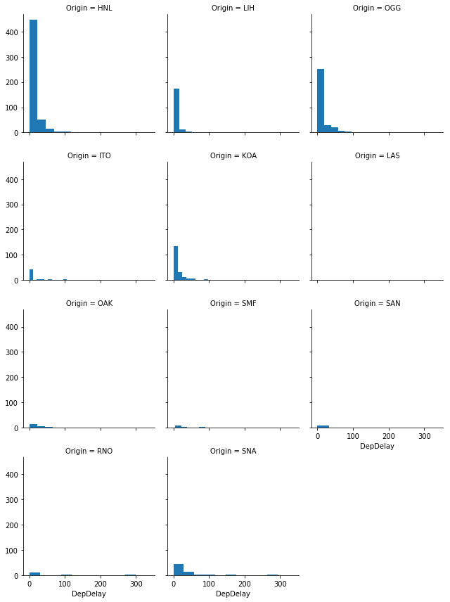

[figure not shown]

```python
g = sns.FacetGrid(data = df, col = 'Origin', col_wrap =3)
g.map(plt.hist, "DepDelay")
figure( figsize=(100, 100))
plt.xlabel('Origin')
plt.xlabel('Departed Delay')
```

##### As we can see there are not any canceled flights

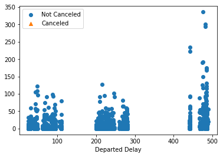

```python
markers = [[0, 'o'],
               [1, '^']]

for m, marker in markers:
    df = df[df['Cancelled'] == m]
    plt.scatter(data = df, x = 'FlightNum', y = 'DepDelay', marker = marker)
plt.legend(['Not Canceled','Canceled'])
plt.xlabel('Flight Number')
plt.xlabel('Departed Delay')
```

##### Those last figures shows the tail number relation to distance and delays

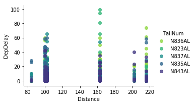

```python
g = sns.FacetGrid(data = df, hue = 'TailNum', hue_order =['N836AL','N823AL','N837AL','N835AL','N843AL'],aspect=1.5,palette='viridis_r')
g.map(sns.regplot,'Distance','DepDelay',x_jitter=0.04,fit_reg=False);
g.add_legend()
#figure(figsize=(100, 100))
```

##### The best flights in this figure are: N843AL N835AL As they have a low delay in minutes weather the flight distance high or low.

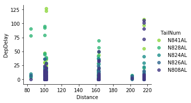

```python
g = sns.FacetGrid(data = df, hue = 'TailNum', hue_order =['N841AL','N828AL','N824AL','N826AL','N808AL'],aspect=1.5,palette='viridis_r')
g.map(sns.regplot,'Distance','DepDelay',x_jitter=0.04,fit_reg=False);
g.add_legend()
```

##### The best flights in this figure are: N826AL As it has a low delay in minutes weather the flight distance high or low.

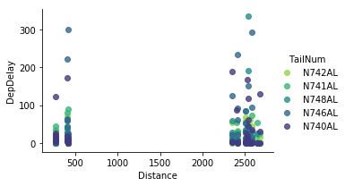

```python
g = sns.FacetGrid(data = df, hue = 'TailNum', hue_order =['N742AL','N741AL','N748AL','N746AL','N740AL'],aspect=1.5,palette='viridis_r')
g.map(sns.regplot,'Distance','DepDelay',x_jitter=0.04,fit_reg=False);
g.add_legend()
```

##### The best flights in this figure are: N741AL N742AL As they have a low delay in minutes weather the flight distance high or low.

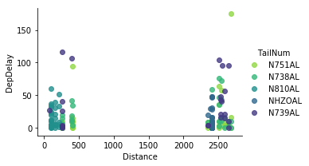

```python
g = sns.FacetGrid(data = df, hue = 'TailNum', hue_order =['N751AL','N738AL','N810AL','NHZOAL','N739AL'],aspect=1.5,palette='viridis_r')
g.map(sns.regplot,'Distance','DepDelay',x_jitter=0.04,fit_reg=False);
g.add_legend()
```

##### The best flights in this figure are: N810AL NHZOAL As they have a low delay in minutes weather the flight distance high or low.

##### Now let's compare all the best airplanes together

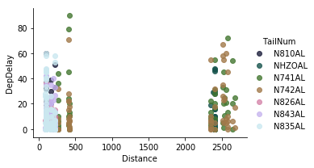

```python
g = sns.FacetGrid(data = df, hue = 'TailNum', hue_order =['N810AL','NHZOAL','N741AL','N742AL','N826AL','N843AL','N835AL'],aspect=1.5,palette='cubehelix')
g.map(sns.regplot,'Distance','DepDelay',x_jitter=0.04,fit_reg=False);
g.add_legend()
```

##### The best flights of all are: N810AL N835AL N843AL N826AL As they have a low delay in minutes weather the flight distance high or low.